# Evaluación curso R

ALBA HERNÁNDEZ, PEDRO

## Entrega

- Recuerda completar tu **nombre en el apartado author**.
- Además del código, no olvides completar las respuestas a las preguntas indicadas en negrita.
- Si tienes dudas/dificultades, **puedes contactar con los profesores**.
- Deadline: Fri 27/06/25
- Puedes realizar la entrega en el mail: **constantino.garciama@ceu.es**.
- La entrega consistirá en el fichero que se genera al hacer `Knit` (un fichero `html` o `pdf`).

> ¡Hola! Escribiré las respuestas que no estén en bloques de código de esta manera. Espero que facilite la lectura…

## Apuestas de adolescentes en UK

El conjunto de datos `teengamb.csv` contiene datos sobre las tasas de juego entre los adolescentes en Gran Bretaña, su género y estatus socioeconómico. Una pregunta que nos puede interesar es **si los ingresos del adolescente y su sexo influyen en la cantidad de dinero apostado (céntrate solo en las variables `income`, `sex` y `gamble`)** … Sigue los siguientes pasos para crear un ANCOVA…

### 1a) Carga los datos…

```r
library(dplyr)
```

```r
library(readr)

# Inspección previa de los datos
readLines(file("./teengamb.csv"), n = 10)
```

```
##  [1] "sex,status,income,verbal,gamble"     "Female,51,2,8,20.965805220659274"
##  [3] "Female,28,2.5,8,-11.0915143856075"   "Female,37,2,6,-8.586762616829967"
##  [5] "Female,28,7,4,17.35173243348922"     "Female,65,2,8,-17.252409368409264"
##  [7] "Female,61,3.47,6,14.878532746499472" "Female,28,5.5,7,-20.798119738462013"
##  [9] "Female,27,6.42,5,-15.74381968331118" "Female,43,2,6,12.179889262158483"
```

```r
# Carga los datos
teengamb = read_csv(
  "./teengamb.csv",
  col_names = T
)
```

### 1b) Visualiza los datos…

…para valorar si el modelo debe incluir interacciones. Para ello, escribe el código que genera una gráfica similar a la siguiente:

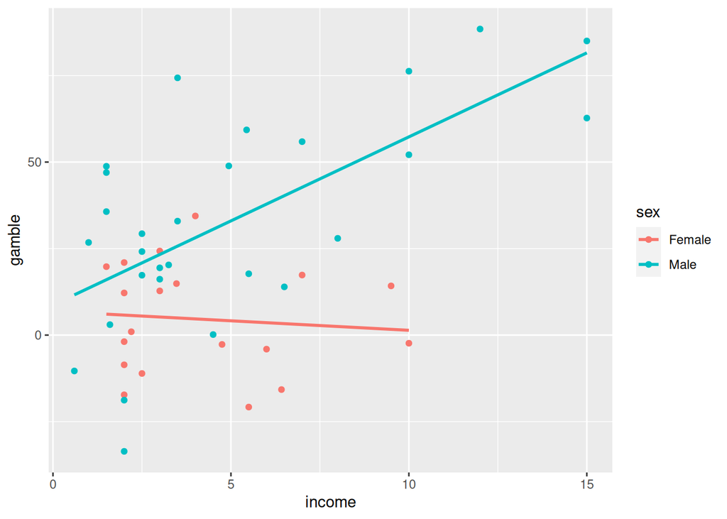

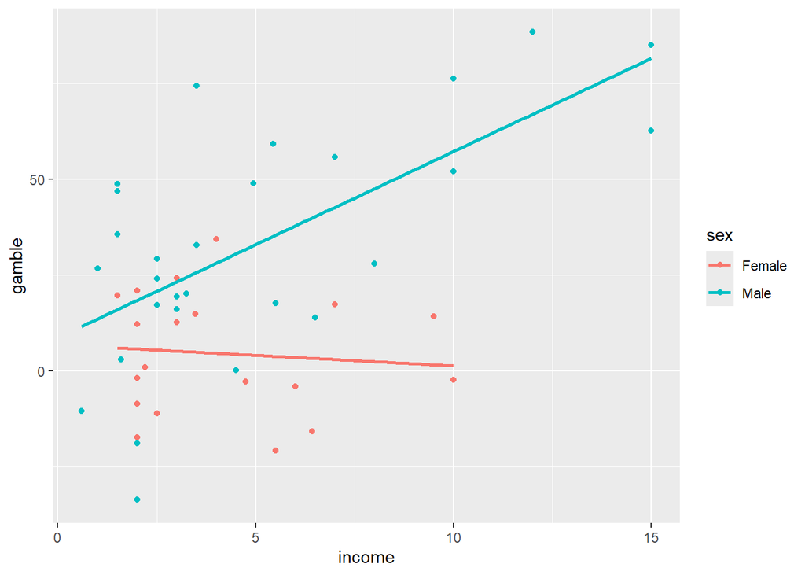

```r
library("tidyverse")  # carga ggplot
# completa el siguiente código
ggplot(teengamb, aes(x = income, col = sex, y=gamble)) +
  geom_point() + # añade la geometría adecuada para los puntos
  geom_smooth(method = "lm", se = FALSE)  # añade las rectas de regresión
```

La gráfica anterior apoya que hay interacciones entre las variables `sex` e `income`. **Explica los motivos brevemente** (Pista: ¿son las rectas paralelas?)

> A mí me da la sensación de que la que “cambia”, la que “interacciona” con `sex` es la variable `gamble`. O, de otra forma, hay correlación entre `income` y `gamble`, pero no es igual en ambos sexos. Si la correlación entre `gamble` e `income` fuese independiente de `sex`, las rectas para ambos sexos serían *más o menos* paralelas. Como no son paralelas, signfica que la variable `sex` “interfiere” en la correlación de ambas muestras.

### 2) Crea el modelo…

… y obtén los intervalos de confianza para los coeficientes y su significación.

```r
# Crea un modelo con interacciones en base a tu conclusión del apartado anterior
gamb_model <- lm(gamble ~ income * sex, data = teengamb)

# Obtén p-valores e intervalos de confianza. Usa summary y confint
summary(gamb_model)
```

```
##
## Call:
## lm(formula = gamble ~ income * sex, data = teengamb)
##
## Residuals:
##     Min      1Q  Median      3Q     Max
## -52.025 -15.479  -3.559  14.022  48.625
##
## Coefficients:
##                Estimate Std. Error t value Pr(>|t|)
## (Intercept)      6.8743     9.2446   0.744   0.4612
## income          -0.5489     1.9024  -0.289   0.7743
## sexMale          1.8427    11.1946   0.165   0.8700
## income:sexMale   5.4050     2.1435   2.522   0.0155 *
## ---
## Signif. codes:  0 '***' 0.001 '**' 0.01 '*' 0.05 '.' 0.1 ' ' 1
##
## Residual standard error: 20.97 on 43 degrees of freedom
## Multiple R-squared:  0.5105, Adjusted R-squared:  0.4764
## F-statistic: 14.95 on 3 and 43 DF,  p-value: 8.279e-07
```

```r
confint(gamb_model)
```

```
##                     2.5 %    97.5 %
## (Intercept)    -11.769152 25.517839
## income          -4.385455  3.287728
## sexMale        -20.733425 24.418773
## income:sexMale   1.082260  9.727751
```

```r
library(effectsize)
effectsize(gamb_model)
```

```
## # Standardization method: refit
##
## Parameter           | Std. Coef. |         95% CI
## -------------------------------------------------
## (Intercept)         |      -0.59 | [-0.93, -0.25]
## income              |      -0.07 | [-0.54,  0.40]
## sex [Male]          |       0.93 | [ 0.49,  1.37]
## income × sex [Male] |       0.66 | [ 0.13,  1.19]
```

> Aquí también he querido comprobar el tamaño del efecto del cambio de pendiente para la recta `gamble~income` para hombres respecto a mujeres. Además de ser un cambio significativo (p-valor <0.05), el efecto del tamaño es también bueno (a mí parecer, ya que se acerca a 1, lo que parece la norma en [FAQ](https://imaging.mrc-cbu.cam.ac.uk/statswiki/FAQ/effectSize)), por lo que me parece correcto decir que, según nuestros datos, los hombres apuestan más a medida que aumenta su salario.

### 3) Valora si las asunciones del modelo se cumplen

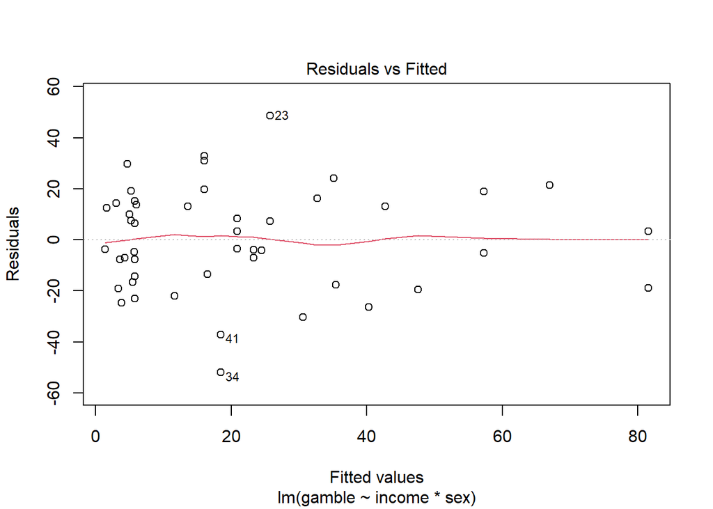

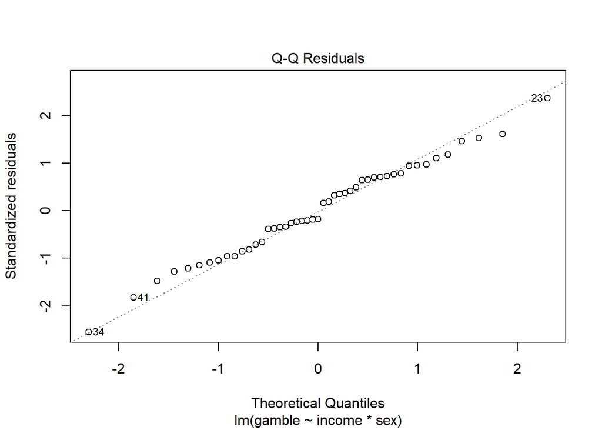

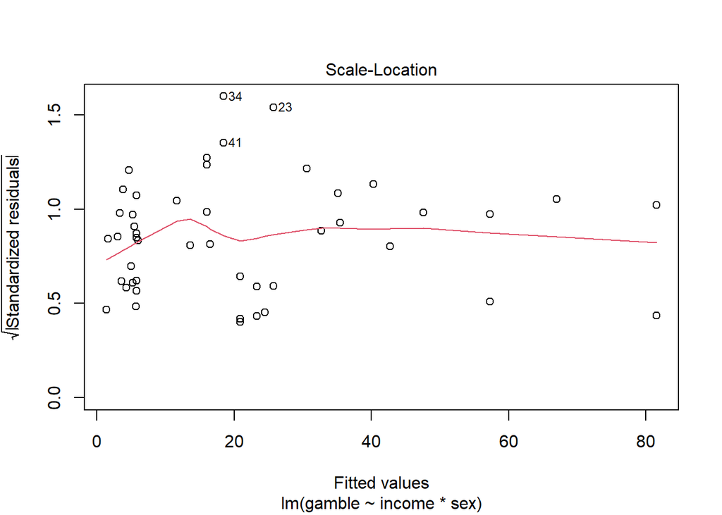

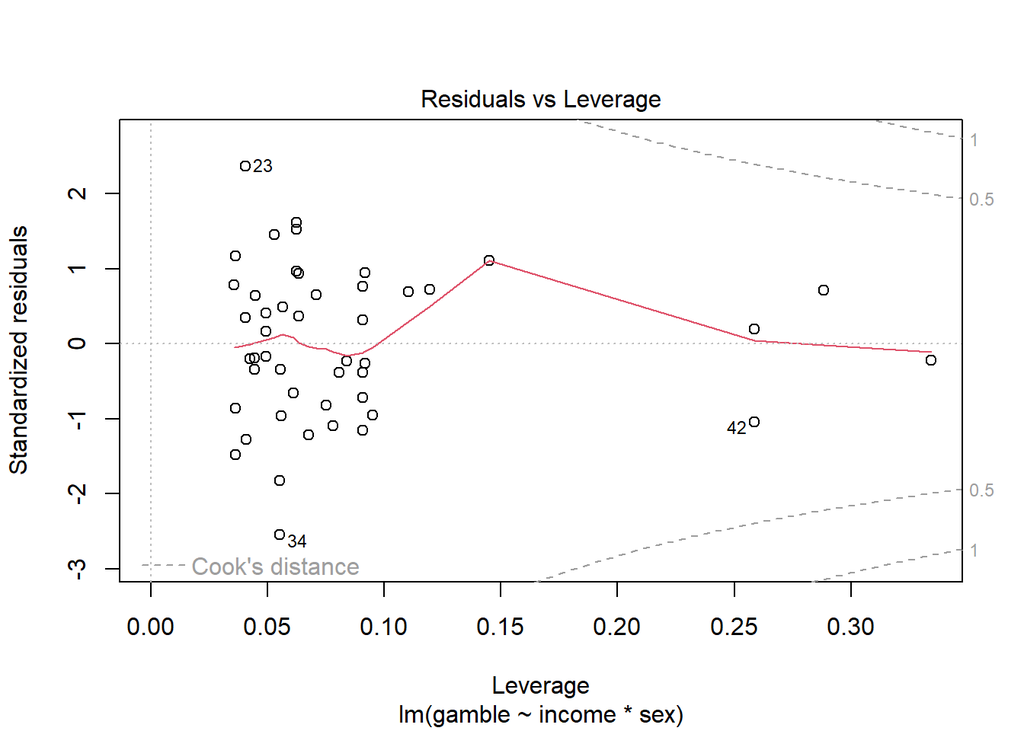

```r
# Interpretar las 4 gráficas siguientes para decidir si las asunciones del modelo
# se cumplen
plot(gamb_model, ask = F)
```

**¿Es el modelo correcto?:**

> A mí me parece que el modelo es válido, ya que:
> 1. En el primer gráfico se observa una línea bastante horizontal, lo que indica que la media de los residuales es cercana a 0 (buen ajuste, Linearidad).
> 2. En el Q-Q plot, los puntos se ajustan bien a la diagonal, indicando que los datos son normales (Normalidad).
> 3. En el tercer gráfico también se observa una línea bastante horizontal, lo que sugiere que la dispersión de los datos (y por lo tanto la varianza) es similar entre las dos variables (Igualdad de varianzas).
> 4. En el último gráfico no hay ningún dato en la “zona de peligro” que indicaría que tiene un peso excesivo en el modelo.

### 4) Interpreta los coeficientes y escribe tus conclusiones.

> Ecuación completa del modelo (según la he entendido):

> $$gamble = intercept + maleCoef * is\_male
> + (incomeCoef + income\_maleCoef * is\_male) * income$$

> $$gamble = 6.87 + 1.843 * is\_male + (-
> 0.5489 + 5.41 * is\_male) * income$$

De la tabla de p-valores, podemos concluir que para las mujeres:
$$gamble = 6.87 - 0.5489 * income$$
Mientras que para hombres:
$$gamble
= 8.72 + 4.8561 * income.$$
Fíjate que el coeficiente -0.5489 no es significativo, mientras que el salto en las pendientes entre mujeres y hombres es de 5.4050 y sí es significativo.

**¿Cuáles de las siguientes conclusiones son correctas? (puede haber varias)**

1. Los hombres y mujeres adolescentes apuestan de la misma forma.
2. No evidencia suficiente de que las mujeres apuesten de forma diferente según sus ingresos.
3. Para los hombres: a mayor nivel de ingresos, mayor cantidad apostada.
4. La diferencia entre las pendientes de hombres y mujeres no es significativa.

> Las respuestas correctas son:

> B, dado que:  
> 1) Al visualizar el modelo no se observa relación aparente, y  
> 2) el p-value es mucho mayor que 0.05, lo que no nos permite descartar la hipótesis nula de que no existe relación entre las variables para mujeres (H0 : pendiente = 0).

> Y C, dado que:  
> 1) Al visualizar el modelo se observa una relación aparente,  
> 2) el p-value es inferior a 0.05, lo que descarta la hipótesis nula y nos indica relación significativa entre las variables para hombres, y  
> 3) el tamaño del efecto según `effectsize::effectsize()` es alto.